# Inference for Categorical Data

## Checking Conditions

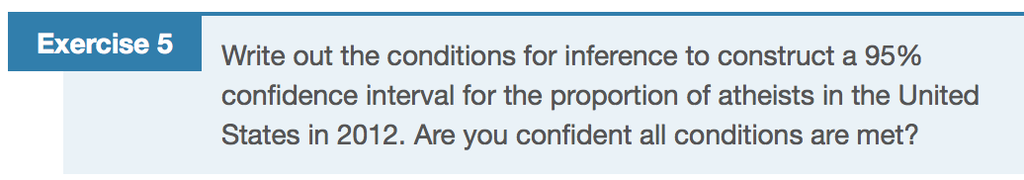

\(\hat{p} \sim N(\mu = p, \sigma = \sqrt{\frac{p(1-p)}{n}})\) if

1. Observations are independent
2. The number of observed successes and failures is more than 10.

\[ np \ge 10 \\ n(1 - p) \ge 10 \]

## Question

We are given that \(n = 1002, \hat{p} = 0.05\). Which of the below is the correct calculation of the 95% confidence interval?

1. \(0.05 \pm 1.96 \sqrt{(.05 \times 0.95)/1002}\)
2. \(0.05 \pm 1.65 \sqrt{(.05 \times 0.95)/1002}\)
3. \(0.05 \pm 1.96 ((.05 \times 0.95)/\sqrt{1002})\)
4. \(50 \pm 1.96 \sqrt{(50 \times 952)/1002}\)

## Constructing a CI

```r
p_hat <- us12 %>%
  summarize(p_hat = mean(response == "atheist"))
nrow(us12) * p_hat
```

```
##   p_hat
## 1    50
```

```r
SE <- sqrt((p_hat * (1 - p_hat)) / nrow(us12))
z_star <- qnorm(.025) # for a 95% CI
z_star
```

```
## [1] -1.96
```

```r
MoE <- z_star * SE
c(p_hat - MoE, p_hat + MoE)
```

```
## $p_hat
## [1] 0.0634
##
## $p_hat
## [1] 0.0364
```

```r
inference(y = response, data = us12, statistic = "proportion",
          type = "ci", method = "theoretical", success = "atheist")
```

```
## Single categorical variable, success: atheist
## n = 1002, p-hat = 0.0499
## 95% CI: (0.0364 , 0.0634)
```

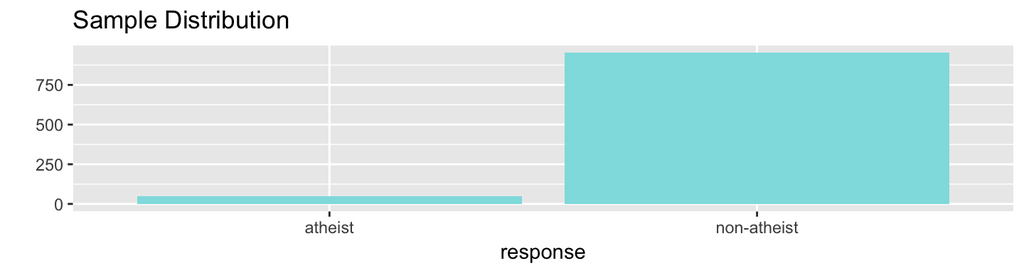

## `inference()` function

[figure not shown]

Your great responsibility:

1. Understand what's going on inside the black box.
2. Ensure the conditions for inference are reasonable.

## When conditions *aren't* reasonable

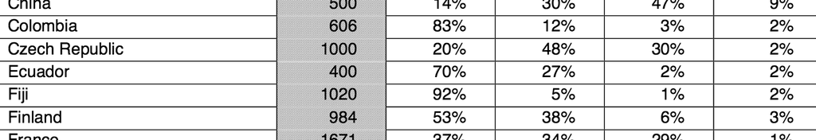

\[ n = 400 \\ \hat{p} = 0.02 \\ np = 8 < 10 \]

Are they doing inference?

Yes! "In general, the …"

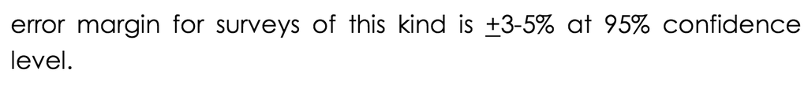

## Simulate the sampling dist.

```r
p <- 0.02
n <- 400
p_hats <- rep(0, 10000)

for (i in 1:10000) {
  samp <- sample(c("atheist", "non_atheist"), size = n,
                 replace = TRUE, prob = c(p, 1 - p))
  p_hats[i] <- sum(samp == "atheist") / n
}
```

## Simulate the sampling dist.

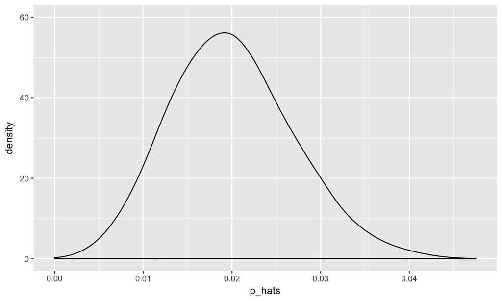

## A poor approximation

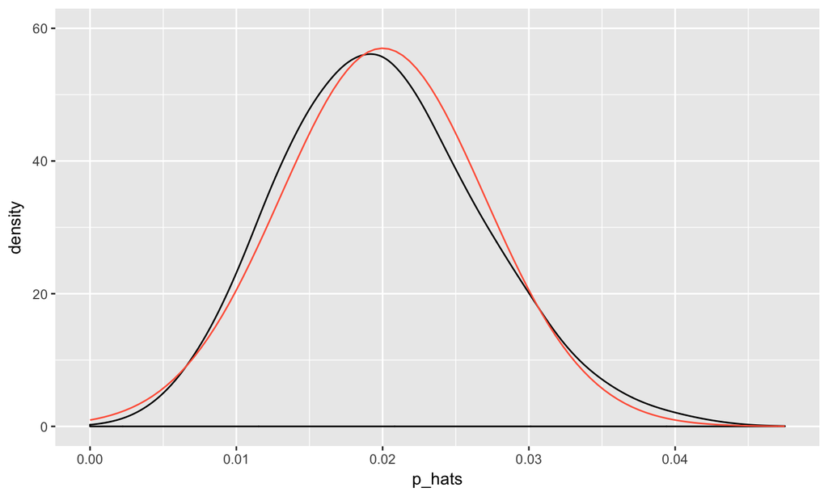

## Double the sample size…

```r
p <- 0.02
n <- 800
p_hats <- rep(0, 10000)

for (i in 1:10000) {
  samp <- sample(c("atheist", "non_atheist"), size = n,
                 replace = TRUE, prob = c(p, 1 - p))
  p_hats[i] <- sum(samp == "atheist") / n
}
```

## A better approximation

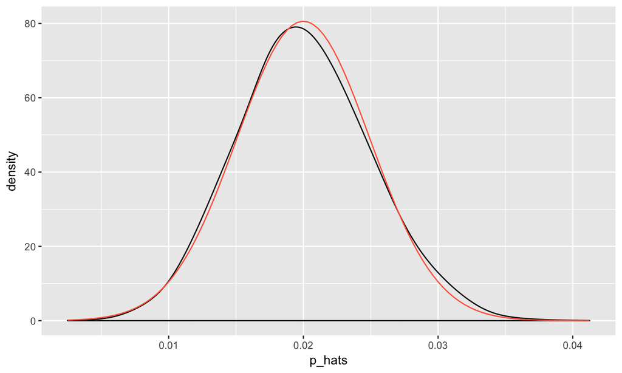

## Increase p…

```r
p <- 0.25
n <- 800
p_hats <- rep(0, 10000)

for (i in 1:10000) {
  samp <- sample(c("atheist", "non_atheist"), size = n,
                 replace = TRUE, prob = c(p, 1 - p))
  p_hats[i] <- sum(samp == "atheist") / n
}
```

## A better approximation

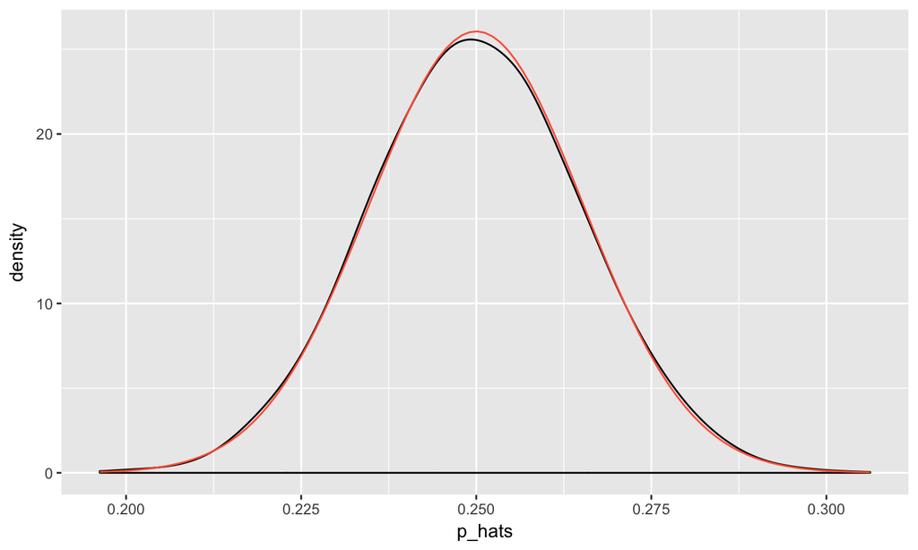

## Interpreting a confidence interval

## Making decisions with confidence intervals

## A reasonable claim?

*A full 10% of Americans are atheist.*

### Claim

\(p = 0.10\)

### 95% CI

\((0.0364 , 0.0634)\)

The claim is *inconsistent* with our estimate of \(p\).

## Extending to two proportions

## Question

Scientists predict that global warming may have big effects on the polar regions within the next 100 years. One of the possible effects is that the northern ice cap may completely melt. Would this bother you a great deal, some, a little, or not at all if it actually happened?

1. A great deal
2. Some
3. A little
4. Not at all

*Are Reed Students different from a random sample of Americans?*

GSS Survey data (2010)

| response | count |
| --- | --- |
| A great deal | 454 |
| Some | 124 |
| A little | 52 |
| Not at all | 50 |
| Total | 680 |

\[\hat{p}_{US} = 454/680 \approx 0.67\]

### Parameter of interest

Difference between the proportions of *all* Reed students and *all* Americans who would be bothered a great deal by the northern ice cap completely melting.

\[p_{Reed} - p_{US}\]

### Point estimate

Difference between the proportions of *sampled* Reed students and *sampled* Americans who would be bothered a great deal by the northern ice cap completely melting.

\[\hat{p}_{Reed} - \hat{p}_{US}\]

## Constructing a CI for \(p_1 - p_2\)

Details same as before:

1. check conditions for using the normal approximation
2. point estimate \(\pm\) margin of error
3. standard error

\[ SE_{\hat{p}_1 - \hat{p}_2} = \sqrt{\frac{p_1(1-p_1)}{n_1} + \frac{p_2(1-p_2)}{n_2}} \]

We swap in \(\hat{p}_1\) and \(\hat{p}_1\) for \(p_1\) and \(p_2\).